# Climate Zones and Happiness in the United States

As we analyzed in the ‘Country’ section, I wanted to see the relationship between climate zones and state-level happiness scores in the United States. By categorizing states into climate zones based on latitude, the analysis explores patterns in happiness distribution and the impact of geography on well-being.

```r
# Load libraries
library(tidyverse)
library(sf)
library(spdep)
library(viridis)
library(readxl)
library(rnaturalearth)
library(rnaturalearthdata)
library(corrplot)
```

```r
# Load spatial and happiness datasets
us_states <- ne_states(country = "United States of America", returnclass = "sf")
happiness_state <- read_csv("../data/happiest-states-2024.csv", show_col_types = FALSE)
```

```r
# Merge spatial and happiness data
merged_sf <- left_join(us_states, happiness_state, by = c("name" = "state"))
merged_sf <- merged_sf[!is.na(merged_sf$`HappiestStatesTotalHappinessScore`), ] # Remove rows with missing happiness scores
```

```r
merged_sf <- st_transform(merged_sf, crs = 3857)
```

```r
# Categorize countries into climate zones
merged_sf$climate_zone <- case_when(
  merged_sf$latitude >= -23.5 & merged_sf$latitude <= 23.5 ~ "Tropical",
  merged_sf$latitude > 23.5 & merged_sf$latitude <= 40 ~ "Sub Tropical",
  merged_sf$latitude < -23.5 & merged_sf$latitude >= -40 ~ "Sub Tropical",
  merged_sf$latitude > 40 & merged_sf$latitude <= 60 ~ "Temperate",
  merged_sf$latitude < -40 & merged_sf$latitude >= -60 ~ "Temperate",
  merged_sf$latitude > 60 | merged_sf$latitude < -60 ~ "Polar",
  TRUE ~ NA_character_ # Assign NA if no condition matches
)


# Compute average happiness by climate zone
climate_stats <- merged_sf %>%
  group_by(climate_zone) %>%
  summarize(avg_happiness = mean(`HappiestStatesTotalHappinessScore`, na.rm = TRUE))

print(climate_stats)
```

```
Simple feature collection with 4 features and 2 fields
Geometry type: MULTIPOLYGON
Dimension:     XY
Bounding box:  xmin: -19942160 ymin: 2143886 xmax: 20013120 ymax: 11544810
Projected CRS: WGS 84 / Pseudo-Mercator
# A tibble: 4 × 3
  climate_zone avg_happiness                                            geometry
  <chr>                <dbl>                                  <MULTIPOLYGON [m]>
1 Polar                 46.3 (((-15696668 10956047, -15696657 10909537, -156966…
2 Sub Tropical          48.5 (((-10817954 3013930, -10818954 3017589, -10821704…
3 Temperate             54.6 (((-10090220 5232504, -10086825 5230602, -10085119…
4 Tropical              66.3 (((-17243347 2221808, -17237447 2219200, -17235075…
```

States are categorized into the following climate zones based on their latitude:

Tropical: Latitudes between -23.5° and 23.5°. Subtropical: Latitudes between 23.5° and 40° (north and south). Temperate: Latitudes between 40° and 60° (north and south). Polar: Latitudes above 60° or below -60°.

The summary statistics suggest that tropical regions exhibit the highest happiness scores, potentially influenced by favorable environmental conditions or cultural factors. Conversely, polar regions show the lowest scores, likely due to harsher climates and limited population density.

### Exploratory Visualizations

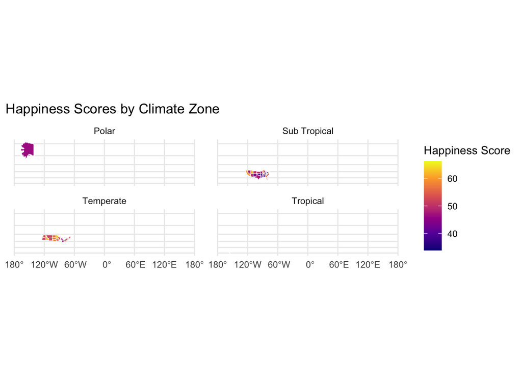

```r
# Visualize happiness scores by climate zone
ggplot(merged_sf) +
  geom_sf(aes(fill = `HappiestStatesTotalHappinessScore`), color = "white") +
  facet_wrap(~climate_zone) +
  scale_fill_viridis_c(option = "C") +
  theme_minimal() +
  labs(title = "Happiness Scores by Climate Zone", fill = "Happiness Score")
```

### Spatial Autocorrelation Analysis

```r
# Subset tropical, sub tropical, temperate, and polar countries
tropical_countries <- merged_sf[merged_sf$climate_zone == "Tropical", ]
subtropical_countries <- merged_sf[merged_sf$climate_zone == "Sub Tropical", ]
temperate_countries <- merged_sf[merged_sf$climate_zone == "Temperate", ]
polar_countries <- merged_sf[merged_sf$climate_zone == "Polar", ]
```

```r
# Calculate centroids for subtropical countries
subtropical_coords <- st_coordinates(st_centroid(subtropical_countries))

# Create spatial weights using k-nearest neighbors
subtropical_knn <- spdep::knearneigh(subtropical_coords, k = 5)
subtropical_listw <- spdep::nb2listw(spdep::knn2nb(subtropical_knn), style = "W")

# Moran's I for subtropical countries
subtropical_moran <- spdep::moran.test(subtropical_countries$HappiestStatesTotalHappinessScore, subtropical_listw)
print(subtropical_moran)
```

```
    Moran I test under randomisation

data:  subtropical_countries$HappiestStatesTotalHappinessScore
weights: subtropical_listw

Moran I statistic standard deviate = 2.5733, p-value = 0.005036
alternative hypothesis: greater
sample estimates:
Moran I statistic       Expectation          Variance
       0.23328472       -0.04000000        0.01127816
```

```r
# Create spatial weights for temperate countries
temperate_coords <- st_coordinates(st_centroid(temperate_countries))
temperate_knn <- spdep::knearneigh(temperate_coords, k = 5)
temperate_listw <- spdep::nb2listw(spdep::knn2nb(temperate_knn), style = "W")

# Moran's I for temperate countries
temperate_moran <- spdep::moran.test(temperate_countries$HappiestStatesTotalHappinessScore, temperate_listw)
print(temperate_moran)
```

```
    Moran I test under randomisation

data:  temperate_countries$HappiestStatesTotalHappinessScore
weights: temperate_listw

Moran I statistic standard deviate = 0.78115, p-value = 0.2174
alternative hypothesis: greater
sample estimates:
Moran I statistic       Expectation          Variance
       0.03863463       -0.04761905        0.01219243
```

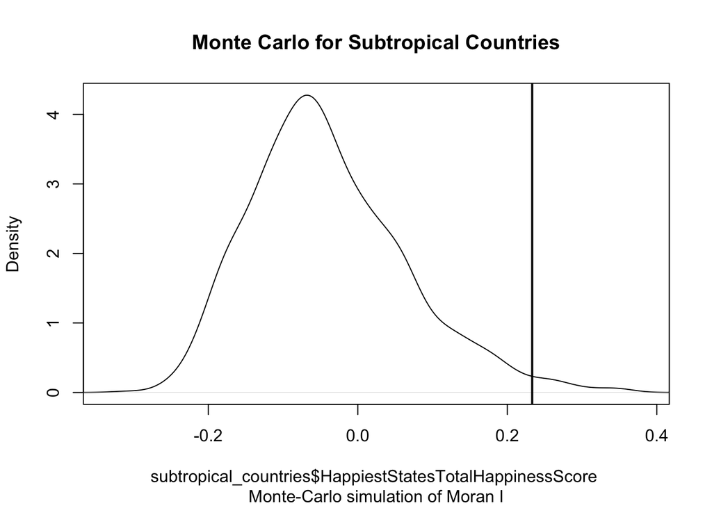

```r
# Monte Carlo simulation for subtropical countries
subtropical_mc <- spdep::moran.mc(subtropical_countries$HappiestStatesTotalHappinessScore, subtropical_listw, nsim = 999)
plot(subtropical_mc, main = "Monte Carlo for Subtropical Countries")
```

```r
print(subtropical_mc)
```

```
    Monte-Carlo simulation of Moran I

data:  subtropical_countries$HappiestStatesTotalHappinessScore
weights: subtropical_listw
number of simulations + 1: 1000

statistic = 0.23328, observed rank = 984, p-value = 0.016
alternative hypothesis: greater
```

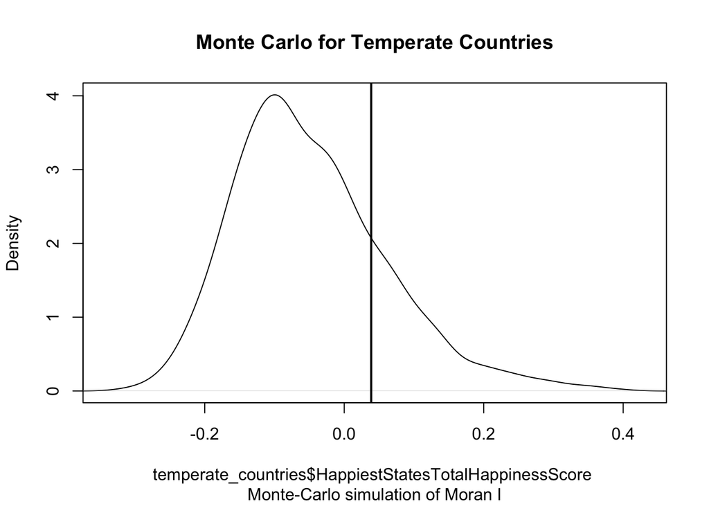

```r
# Monte Carlo simulation for temperate countries
temperate_mc <- spdep::moran.mc(temperate_countries$HappiestStatesTotalHappinessScore, temperate_listw, nsim = 999)
plot(temperate_mc, main = "Monte Carlo for Temperate Countries")
```

```r
print(temperate_mc)
```

```
    Monte-Carlo simulation of Moran I

data:  temperate_countries$HappiestStatesTotalHappinessScore
weights: temperate_listw
number of simulations + 1: 1000

statistic = 0.038635, observed rank = 804, p-value = 0.196
alternative hypothesis: greater
```

Spatial autocorrelation was tested within each climate zone using Moran’s I and Monte Carlo simulations.

For the subtropical zone, we found the Moran’s I = 0.233 and a p-value = 0.005. Significant clustering of happiness scores indicates that neighboring subtropical states tend to share similar happiness levels.

Monte Carlo simulations confirmed the statistical significance of clustering in the subtropical zone but not in the temperate zone. This highlights regional differences in how geography influences happiness.

### Findings

- Tropical regions exhibit the highest happiness scores, possibly due to a combination of favorable climates, outdoor recreation opportunities, and cultural factors.
- Polar regions show the lowest happiness, reflecting challenges associated with colder climates, such as isolation and limited resources.
- Subtropical states demonstrate significant spatial clustering, suggesting regional factors like economic or cultural similarities contribute to shared well-being.